# Penser la démocratie

Démocratie directe et démocratie représentative

Auteur·rice

Skarbimir Prokopek

## Introduction

Pourquoi la démocratie s’impose-t-elle comme un **objet de réflexion** , et cela de manière suffisamment claire et pressante pour être interrogée dans un programme scolaire?  
Pour répondre à cette question, avant de se lancer dans la perspective historique sur l’invention de la démocratie, ou de l’une de ses formes, il faut regarder plus près, vers la manière dont la démocratie, dans sa variété actuelle, libérale, s’est mise à **douter d’elle-même**.

Un tour d’horizon de la situation politique internationale montre des sujets d’inquiétude. Aux **États-Unis**, traditionnellement vus comme un modèle de la démocratie, première république moderne qui vit encore selon une Constitution datant de la fin du xviii<sup>e</sup> siècle, certes amendée plusieurs fois, la démocratie recule visiblement et rapidement avec la réélection de Donald Trump. Dans plusieurs pays européens, la montée des partis d’extrême-droite (en Italie, la première ministre Giorgia Meloni est issue d’une extrême-droite qui se réclame explicitement du fascisme de Benito Mussolini) laisse craindre des reculs des libertés démocratiques. La Hongrie, où Victor Orbàn a été au pouvoir de 1998 à 2002, puis de 2010 à 2026, demeure un modèle de *régime illibéral* ou *populiste*.  
Plus profondément, le **doute** s’attache, de manière croissante, au fonctionnement même des démocraties modernes. Tandis que des bouleversements politiques récents (élection de D. Trump, le *Brexit*) font apparaître les démocraties libérales occidentales comme moins stables, moins résistantes aux dérives autoritaires, le **malaise** croissant s’attache à la qualité démocratique de nos régimes, que nous avons pourtant habitude de désigner comme des démocraties.  
Le mouvement des **Gilets jaunes**, en France (2018-2019), pose très explicitement ce problème: le **référendum d’initiative citoyenne (RIC)**, et plus généralement, l’intervention directe des citoyens dans la vie politique, à l’opposé d’un système purement représentatif qui laisse les élus agir à leur guise entre les élections, devient la revendication emblématique. Le mouvement oppose une volonté et une colère populaire à une légitimité formelle, issue de la procédure électorale, dont se prévaut le gouvernement et le président de la République.

Un retour réflexif sur la démocratie – et d’abord, notre démocratie, c’est-à-dire celle qui existe concrètement à notre époque – s’impose donc.  
La démocratie actuelle est, à quelques expériences très minoritaires près, la démocratie libérale représentative. Ce modèle se forme au cours du xix<sup>e</sup> siècle, à partir des inspirations plus anciennes.  
Ces dernières sont très nombreuses. La **démocratie athénienne** est un symbole célébré mais très peu mobilisé dans le concret. La **république romaine**, oligarchique et très peu démocratique, est une référence beaucoup plus présente, aussi bien sur le plan symbolique que du point de vue des mécanismes institutionnels concrets, tant pour les révolutionnaires français que pour les auteurs de la constitution américaine. D’autres références possibles sont quasi oubliées: ainsi, les républiques italiennes du Moyen Âge, dont deux, Venise et Gênes, ont survécu jusqu’à la fin du xviii<sup>e</sup> siècle, n’intéressent que peu.  
À l’époque moderne, l’Angleterre s’impose comme premier modèle. La *Glorieuse révolution* de 1688, suivie l’année suivante du *Bill of Rights*, se transforme en monarchie parlementaire, où le pouvoir du roi est limité et les individus jouissent de la protection de leur liberté personnelle et de leurs biens contre l’arbitraire royal.  
Cet héritage politique est repris par la révolution américaine, qui l’enrichit d’autres réflexions, dont le modèle légué par la Fédération des Cinq (plus tard, Six) Nations iroquoises, pour fonder la première république moderne, fondée sur un système électoral complexe.  
D’un point de vue actuel, il faut donc noter un premier paradoxe: alors que de très nombreuses républiques ne sont en rien démocratiques, plusieurs parmi les régimes considérés comme des démocraties exemplaires, sont des monarchies parlementaires (le Royaume-Uni, les Pays-Bas, la Suède, la Norvège…). Notablement, pour les pères fondateurs des États-Unis, notamment les plus conservateurs d’entre eux, comme **Hamilton** ou **Madison**, ne voyaient pas la république qu’ils étaient en train d’instituer comme une démocratie: au contraire, la démocratie leur paraissait comme un repoussoir.

À l’issue de la Seconde Guerre mondiale, la démocratie libérale, inspirée du modèle anglo-américain, mais aussi, parfois, français, s’impose en Europe: l’Italie adopte une constitution inspirée de la IV<sup>eme</sup> République française, l’Allemagne se dote d’une constitution démocratique modérée, rédigée par des juristes allemands de manière à éviter le retour d’un pouvoir autoritaire et militariste; l’Europe du Nord reste attachée à la monarchie constitutionnelle. La **décolonisation** voit des républiques s’organiser en Afrique et en Asie. Ainsi, l’Inde proclame, dans le **Préambule de la Constitution adoptée en 1949**:

> Nous, le Peuple de l’Inde, ayant solennellement résolu de constituer l’Inde en une République souveraine, socialiste, laïque et démocratique et d’assurer à tous ses citoyens:

> Justice, sociale, économique et politique;

> Liberté de pensée, d’expression, de croyance, de foi et de culte;

> l’égalité de statut et de chances; et de promouvoir parmi eux tous

> fraternité assurant la dignité de l’individu ainsi que l’unité et l’intégrité de la Nation;

À la **fin du xx<sup>e</sup> siècle** la démocratie libérale gagne l’Europe de l’Est (bien que la transition soit vécue comme un échec en Russie et reste longtemps incertaine en Ukraine). **Samuel Huntington**, auteur emblématique de l’ambiance intellectuelle des années 1990, parle dans un ouvrage de 1991 de la *Troisième vague de démocratie*, qui aurait débuté en 1974 avec la **Révolution des Œillets** au Portugal, suivie par plusieurs pays sud-américains qui sortent des dictatures, ainsi que des pays asiatiques (Corée du Sud, Taïwan). S. Huntington suggère un lien entre cette vague de démocratisation et le catholicisme (qui s’ouvre et modernise avec le **concile de Vatican II** en 1962), les pays protestants étant déjà démocratiques.  
Dans les années 1990 et 2000, la démocratie libérale apparaît comme un modèle triomphant à qui ne résistent que des régimes exceptionnels et, à la longue condamnés, telle la Corée du Nord. Il est alors fréquent d’anticiper une démocratisation à l’occidentale en Chine, voire à Cuba. Le politiste américain **Francis Fukuyama** exprime cet état d’esprit lorsqu’il relance l’idée de la *fin de l’histoire*: après la fin de la Guerre froide, la démocratie libérale et l’économie de marché n’auraient plus d’adversaire, ni de concurrence, et serait appelées à s’imposer universellement.

Or, l’expérience des dernières décennies a fragilisé ces certitudes. La question à laquelle les démocraties actuelles sont confrontées est bien celle de la **représentation**: principe fondamental des régimes actuels, elle est remise en doute. Les contestations récentes (les Gilets jaunes, mais aussi les mouvements d’occupations antérieurs, comme *Occupy Wall Street* en 2011, la *Puerta del Sol* à Madrid, la même année, le Parc Gezi à Istanbul en 2013, ou encore la Nuit Debout à Paris en 2016), contestent la validité de la représentation en pointant que les représentants tendent à suivre leur propre intérêt plutôt que celui de leurs électeurs.

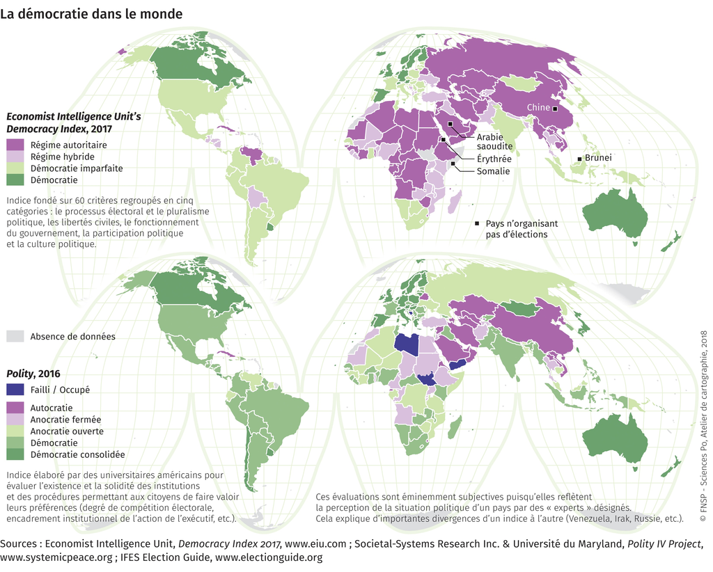

Deux classements du niveau de démocratie dans le monde

## 1 Le germe athénien

J’emprunte ce titre à **Christophe Pébarthe**, auteur du récent ouvrage *Athènes, l’autre démocratie. V<sup>e</sup> siècle av. J.-C.* (2022). L’introduction de l’ouvrage fait explicitement référence au programme de HGGSP en Première et critique une image de la démocratie athénienne trop «moderne», faisant d’Athènes seulement une tentative lointaine et incomplète. Le même texte interroge les deux exclusions que l’on reproche couramment aux Athéniens: celle des femmes et celle des esclaves. Il ne fait pas de doute que les **femmes** n’accèdent pas à la **délibération**.  
Pourtant, les Athéniens connaissent le mot *citoyenne*; les femmes transmettent la citoyenneté, et plus encore après la loi de Périclès qui durcit les conditions de l’accès à la citoyenneté. Elles ne sont pas complètement absentes de la vie publique, surtout à travers des prêtrises qu’elles exercent.  
L’exclusion des esclaves – que l’auteur de la *Constitution des Athéniens*, membre de l’école aristotélicienne, surnommé par les historiens *Vieil Oligarque* en raison de sa haine de la démocratie, reproche aux Athéniens de laisser les esclaves et les **métèques** parler à l’Agora. Ce n’est pas le cas, mais la démocratie peut accepter la possibilité d’intégrer des esclaves dans la citoyenneté, geste qui est envisagé lors de la restauration de la démocratie après la tyrannie des Trente tyrans, mais abandonné à la suite d’un procès en *graphê paranomôn*, ou action en illégalité.

### 1.1 La conquête de l’égalité politique

La démocratie athénienne n’est pas immobile. La plupart des présentations synthétiques donnent un tableau des institutions athéniennes telles qu’elles se présentent au iv<sup>e</sup> siècle, tout en privilégiant l’histoire des guerres médiques et de l’âge de Périclès. Si la démocratie athénienne, qui tient, schématiquement, deux siècles, donne la preuve de sa capacité à durer et à surmonter des crises profondes, elle n’est pas figée dans le temps. Autour des principes fondamentaux, posés ou en tout cas attribués au législateur **Solon**, puis par **Clisthène**, elle évolue.

#### 1.1.1 Solon

Solon est reconnu comme un père fondateur de la démocratie athénienne; le personnage est connu à travers des fragments de textes relativement limités mais, contrairement à son prédécesseur **Dracon** (dont le nom a donné le mot «draconien»), il est bel et bien un personnage historique et non légendaire. **Archonte** au début du vi<sup>e</sup> siècle (594-593 av. J.-C.), il est appelé à résoudre une crise sociale. Issu lui-même de l’aristocratie, il est considéré comme fondateur d’une première forme de démocratie, en tout cas il en pose des fondements.  
La crise qui frappe alors Athènes voit le corps civique fondre: les Athéniens plus pauvres s’endettent massivement, puis tombent dans l’**esclavage pour dettes**, alors que les propriétaires terriens accaparent les terres.  
Solon met en place la *seisachtheia*, ou «allègement du fardeau»: l’esclavage pour dettes est aboli, ceux qui y sont tombés sont **affranchis**. Les dettes impayées sont annulées. Ainsi, la catégorie des *hectemores*, ou serfs, disparaît. Solon instaure ainsi un degré d’égalité entre citoyens: l’abolition des dettes protège l’intégrité du corps civique et vise à empêcher sa destruction par les inégalités croissantes.  
Cependant, Solon n’instaure pas l’égalité parfaite des citoyens, comme il peut arriver lors de la **fondation de nouvelles cités**: plutôt que de procéder à une redistribution de la richesse commune (essentiellement, de la terre du territoire civique), Solon instaure **4 classes censitaires** (les *pentacosiomedimnes*, ou ceux qui disposent de plus de 500 mesures de blé, vin ou olives; les *hippeis* ou cavaliers, définis comme ceux qui disposent de plus de 300 mesures par an; les *zeugites*, dont le nom signifie qu’il possèdent un attelage, et qui atteignent 200 mesures par an de revenu, et enfin les *thètes*, journaliers sans propriété, qui sont aussi **exclus des magistratures**). Ces classes de richesse se substituent à une hiérarchie de naissance.

Solon fonde aussi l’**Héliée**, le tribunal du peuple dont les juges sont **tirés au sort**, et auquel tous les citoyens ont accès. Le **droit de défense et d’accusation** est étendu à tous les citoyens.

> De tous les desseins pour lesquels j’avais rassemblé le peuple, lequel n’avais-je pas accompli quand je me suis retiré ? Sur ce point, la meilleure témoignage, dans le tribunal du Temps, sera la grande mère des dieux olympiens, la Terre noire: d’elle, j’ai arraché les bornes plantées de toutes parts[^1] ; auparavant elle était esclave, maintenant elle est libre.

> Et beaucoup d’hommes, vendus – les uns légalement, les autres illégalement –, je les ai ramenés à Athènes, leur patrie fondée par les dieux; d’autres, qui avaient fui sous la contrainte de la nécessité, ne parlant plus la langue attique, tant ils avaient erré au loin, et d’autres encore, qui supportaient ici une honteuse servitude et tremblaient devant le caractère de leurs maîtres, je les ai affranchis.

> Tout cela, je l’ai accompli par la force de la loi, en unissant la violence et la justice, et j’ai tenu jusqu’au bout mes promesses.

> J’ai rédigé des lois semblablement pour le mauvais et pour le bon, ajustant à chacun une justice droite.

> Solon, Fragment 36 West

<sup>1</sup> la Terre divinisée (Gaïa) est invoquée ici comme un témoin divin; les *horoi*, ou bornes, sont les symboles de la mise sous hypothèque, donc leur suppression est la manifestation de la *seisachtheia*

Le dernier passage de ce fragment fait référence à un principe d’**égalité devant la loi**: même loi pour tout le monde. Or, ce principe d’égalité devant la loi, ou *isonomia*, est aux yeux des Athéniens eux-mêmes synonyme de la démocratie.

#### 1.1.2 Clisthène

La deuxième étape décisive de la fondation de la démocratie athénienne intervient à la toute fin du vi<sup>e</sup> siècle, après l’assassinat du **tyran Hippias**. C’est à cette occasion que la démocratie athénienne mature est instaurée, sous la forme déjà proche de ce qu’elle sera tout au long du v<sup>e</sup> et iv<sup>e</sup> siècle.  
L’assemblée du peuple, ou l’*Ecclésia*, existait déjà, ainsi que l’Héliée, mais Clisthène étend ses pouvoirs. Le Conseil des Quatre-Cents est remplacé par la **Boulè** (littéralement la «Volonté»), dont les membres sont tirés au sort et alternent régulièrement.

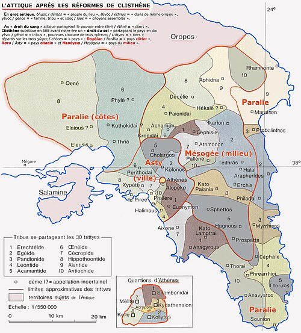

Carte de l’organisation territoriale de l’Attique

Un aspect sous-estimé de la réforme clisthénienne est la division du territoire et de la population en **tribus**, **trittyes** et **dèmes**. Ces derniers sont la division fondamentale, à la fois administrative et politique, dans laquelle on délibère sur les questions locales, on accède à la citoyenneté par l’inscription dans un dème (selon le droit du sol), et on y tire au sort les représentants. Le découpage en dèmes donne du poids à l’**échelle de la connaissance** (les dèmes correspondent à des quartiers urbains ou des regroupements de hameaux ruraux, dont la population ne dépasse pas 1200 personnes selon la plupart des estimations, les **démotes** se connaissent donc personnellement) et permet la représentation égale de toutes les parties du territoire de la cité, que l’on divise traditionnellement entre *Astu*, la ville, la *Mésogée*, ou la campagne, et la *Paralia*, ou la côte.

#### 1.1.3 Périclès

Les réformes de Périclès radicalisent la démocratie. Son ami et mentor, Éphialtès, avait obtenu une forte réduction de l’autorité de l’**aréopage**, conseil traditionnel et dominé par l’aristocratie. Périclès prolonge cette politique en faisant abaisser la seuil de richesse nécessaire pour être **archonte**. Il étend l’accès à l’exercice concret de la citoyenneté: après la gratuité des spectacles théâtraux pour les plus pauvres (ce qui est loin d’être anecdotique, le théâtre antique n’est pas un divertissement mais une cérémonie civique et religieuse!), puis, fait voter la distribution du *misthos*, une indemnité de 2 oboles par jour, accordée aux **héliastes**, puis aux autres magistrats et aux soldats. Ce «gage», intéressant pour les plus pauvres mais ridicule pour les aristocrates, permet aux citoyens qui travaillent de supporter l’effort d’interrompre le travail pour s’investir dans les charges civiques.  
Inversement, la réforme de Périclès de 451 av. J.-C. restreint l’accès à la citoyenneté: désormais, il faut une double filiation par le père et par la mère, ce qui l’oblige d’ailleurs à faire voter une exception pour ses propres enfants, puisque sa femme, **Aspasie**, était originaire de Milet.

### 1.2 Les institutions: la délibération et la représentation

#### 1.2.1 Les grands principes

Avant d’entrer dans le détail des institutions, rappelons les principes fondateurs de la démocratie grecque, que nous pourrons par la suite rapporter à la pratique politique contemporaine.

Le premier est l’**isonomia**. Dans le langage politique athénien, ce mot est souvent synonyme de la démocratie, voire apparaît plus souvent que *dêmokratia*. La définition simple est l’égalité devant la loi, principe d’égalité juridique qui n’exclut pas, par ailleurs, de grandes inégalités économiques entre individus.  
L’historien **Jean-Pierre Vernant** en donne une définition saisissante, restée célèbre:

> Le terme isonomia signifie que personne ne commande à personne, c’est la loi, un principe abstrait qui commande à tous. C’est la loi qui a le pouvoir.

Dans un entretien radiophonique, le même historien développe un peu plus:

> Au lieu que la société humaine forme, comme l’espace mythique, un monde à étages avec le roi au sommet et au-dessous de lui toute une hiérarchie de statuts sociaux définis en termes de domination et de soumission, l’univers de la cité apparaît constitué par des rapports égalitaires, réversibles où tous les citoyens se définissent par rapport aux autres comme identiques sur le plan politique.

Le second est l’*isêgoria*, ou capacité égale à accéder à l’espace de la parole publique (l’Agora), à prendre la parole, dans le temps imparti, limité par l’usage de la **clepsydre**, à proposer des résolutions et argumenter.

Le troisième, et peut-être aussi important que le premier, est la **parrhésie** (ou *parrêsia*), ou la possibilité pour chaque citoyen de dire le vrai pour tous. N’importe quel citoyen a la capacité à exprimer la vérité devant le peuple et dans l’intérêt général. Ce principe est essentiel et exclut toute possibilité de délégation: si l’on peut élire un magistrat ou en désigner un par tirage au sort, il n’est pas envisageable de déléguer la parrhésie.

#### 1.2.2 Le peuple délibérant: l’Ecclésia et l’Héliée

Les deux institutions clés de la démocratie athénienne sont l’Ecclésia, l’assemblée du peuple, et le tribunal fondé par Solon, l’Héliée.

L’**Ecclésia** est en principe la réunion de l’entièreté du corps civique: jusqu’à 40 000 citoyens pourraient théoriquement s’y rendre (pour une population totale de 200 ou 300 mille habitants). En pratique, la totalité des habitants n’est jamais présente, l’espace disponible à l’Agora, puis sur la colline du **Pnyx** limite les assemblées à 6000 participants. Ce chiffre, que nous rencontrons ailleurs dans les institutions athéniennes, est hautement symbolique. Il correspond aussi au *quorum* exigé pour certaines décisions particulièrement importants, comme l’ostracisme ou la naturalisation d’un nouveau citoyen. Dans la pratique, l’absentéisme existe, et est dénoncé par certains auteurs, en particulier **Aristophane**. La participation est exigée: les esclaves publics (archers scythes) déploient une corde couverte de colorant pour marquer les citoyens se dérobant à l’assemblée, qui pouvaient être privés du *misthos*.  
L’Ecclésia vote les lois, mais elle décide aussi en matière de guerre, de paix et des alliances, ou encore des dépenses. Elle élit les stratèges et désigne par tirage au sort les **héliastes** et les **bouleutes**, ainsi que les **archontes**, qui ont perdu l’essentiel de leur pouvoir à l’époque de Périclès.

[video not shown]

Par conséquent, à la différence des parlements modernes, l’Ecclésia (donc, le peuple), **gouverne**, alors que les assemblées actuelles ne font que légiférer. Encore plus important, à la différence des référendums modernes, l’Ecclésia ne se contente pas de trancher une décision posée par d’autres, mais **délibère**: une véritable discussion y a lieu, et l’avis du peuple peut changer si de nouveaux arguments sont apportés.

L’**Héliée** émane de l’Ecclésia, par voie du tirage au sort, on pourrait donc hésiter à la mettre sur le même plan. Mais à Athènes, les pouvoirs **ne sont pas séparés**; la justice est explicitement politique.  
Les héliastes sont désignés par tirage au sort, parmi les volontaires. Ils sont 600 par tribu, ce qui ramène au nombre symbolique de 6000. Ils ne siègent pas tous en même temps, mais à tour de rôle, répartis en jurys par des magistrats nommés **thesmothètes**. Les jurés perçoivent le **misthos** instauré par Périclès, porté ensuite à 3 oboles par Cléon. Les auteurs comiques nous montrent des pauvres et des vieillards se presser aux portes de l’Héliée pour percevoir ce paiement, puis déserter le tribunal à la première occasion.  
Même si l’institution judiciaire athénienne est éloigné des conceptions modernes, il faut y reconnaître un élément clé de la démocratie, dans lequel le peuple est présent directement.

#### 1.2.3 Représentation et délégation à Athènes: les magistratures

Affirmer que la démocratie athénienne est directe ne signifie pas que la représentation et la délégation de responsabilité en soit totalement absente. La démocratie athénienne repose dans son fonctionnement quotidien sur un nombre important de magistratures. Le **Conseil des Cinq-Cents**, ou **Boulè**, a un pouvoir important dans la mesure où il contrôle l’ordre du jour des séances de l’Assemblée. Les membres sont désignés par tirage au sort, parmi les volontaires, à raison de 50 par tribu, sur des listes établies dans les dèmes. Après la réforme de Périclès, les bouleutes reçoivent aussi le *misthos*, puisque pendant l’année où ils sont conseillers, ses membres n’ont pas le temps de travailler. Les bouleutes prennent en note les propositions de loi, qu’ils élaborent pour préparer une *probouleuma*, qui est placée dans l’ordre du jour et soumise au vote de l’Assemblée. Les *probouleumata* sont transmis aux *prytanes*, ou bouleutes d’une même tribu qui assurent pendant un mois une présidence tournante du Conseil. Un parmi eux, qui change chaque jour, est l’*épistate* dont le nom est cité dans un décret pour le dater, et qui porte la responsabilité en cas de l’accusation d’illégalité. Ainsi le pouvoir circule dans la société.

La plupart des autres magistratures – dont il est inutile de faire la liste complète – sont également soumises au tirage au sort. C’est même le cas des **archontes**, anciennement la plus haute magistrature athénienne. Plus que les attributions exactes de telle ou telle magistrature, est intéressante l’opposition entre les démocrates (dont Périclès est, en son temps, le chef de file) et les oligarques. Les premiers expriment les intérêts des moins fortunés et sont le parti de la mer. Il existe un lien étroit, souligné par J.-P. Vernant et par **Jean Rougé** entre la démocratie et la navigation: la flotte dépend en effet d’un grand nombre de spécialistes, marins mais aussi artisans qui construisent en entretiennent les bateaux, et qui contribuent à l’effort général par leur savoir-faire (*tekhnè*) et fournit un vecteur de promotion sociale aux *thètes* (quatrième classe censitaire de Solon, exclus des magistratures).  
À l’opposé, les partisans de l’oligarchie sont plutôt des propriétaires terriens et leur référence symbolique est l’**hoplite de Marathon**: le combattant d’infanterie lourde, équipé à ses propres frais d’un armement complexe et cher.

La magistrature de **stratège**, que Périclès occupe pendant une quinzaine d’années, est l’une des rares élues. En pratique les stratèges sont des hommes politiques mais l’attribution principale liée à cette magistrature était le commandement militaire, ce qui explique le maintien de l’élection. Mais même cette magistrature suprême est collégiale: les stratèges sont 10, un par tribu, et assurent une présidence tournante.

Ajoutons aux magistratures proprement dites, les **liturgies**. Il s’agit d’un dispositif plus proche de la fiscalité: les individus fortunés assumaient, de manière volontaire, les frais d’un bien commun. Il peut s’agir des besoins rituels (les sources mentionnent un liturge qui se charge de la consécration d’un trépied; les *chorégies* concernent les fêtes publiques), mais aussi militaires: les *trierarches* arment une trière pour la cité.

Un dernier aspect: l’historien Paulin **Ismard** a souligné le rôle des **esclaves publics** à qui sont confiées diverses tâches techniques nécessaire pour faire fonctionner les institutions: la police (les archers scythes dont on a déjà parlé), la tenue des archives et certains comptes, gestion des tirages au sort etc. C’est donc un corps de fonctionnaires, voire une bureaucratie, certes relativement peu développée (on parle d’environ 1000-2000 agents).

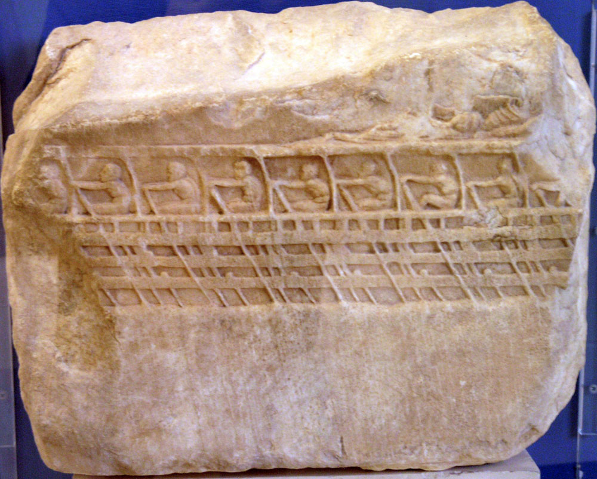

Relief Lenormant, vers 410-400 av. J.-C., musée de l’Acropole d’Athènes, illustrant la trierarchie

#### 1.2.4 Contrôle et défense de la démocratie

La démocratie n’est pas seulement un régime mouvant, elle est en permanence menacée et doit être défendue. La défaite dans la Guerre du Péloponnèse mena à l’installation d’un régime aristocratique des «Trente tyrans» au bout d’un siècle de démocratie.

Le mécanisme le plus connu est l’**ostracisme**. Il est impératif de se détacher du sens moderne et courant de ce mot, qui a fini par désigner le rejet social d’une personne. La procédure d’ostracisme, attribuée à Clisthène, règle et limite la pratique des expulsions qui avaient eu lieu à une échelle plus grande: au vi<sup>e</sup> siècle des familles nobles (**genè**) avaient été expulsées collectivement. À la chute de la tyrannie, seulement les tyrans et leurs fils sont bannis, mais la menace d’un bannissement pour dix ans pèse sur les autres membres de la famille des Pisistratides, qui sont alors obligés de se tenir à l’écart de la politique. Le premier ostracisme a lieu en 488 av. J.-C., d’après Aristote. Le dernier ostracisé fut Hyperbolos, banni en 417. L’institution est alors déjà critiquée; par la suite et tout au long du iv<sup>e</sup> siècle l’ostracisme n’est pas utilisé.

La procédure se déroule en deux temps: d’abord on vote en Assemblée pour savoir si l’année en cours on doit ou non procéder à l’ostracisme: à ce stade, on ne cite pas de noms. S’il est décidé d’ostraciser quelqu’un, lors d’une séance plénière de l’Assemblée, tenue lors de la prytanie suivante, on procédait à un vote (l’*ostracophorie*) lors de laquelle les citoyens déposaient à l’endroit désigné les tessons portant les noms des candidats à l’ostracisme. Selon Plutarque, le *quorum* de 6000 votes était requis; l’interprétation traditionnellement admise est qu’il fallait un minimum de 6000 votes visant un même individu pour que l’ostracisme fût effectif. Le temps qui s’écoule entre les deux votes permet de mener une campagne, avec des discours en faveur du bannissement de telle ou telle personne. Nous avons des preuves archéologiques qui montrent que l’ostracisme est préparé dans le cadre des factions des partisans des principales personnalités politiques: Plutarque cite ainsi le bannissement de Cimon à l’initiative de Périclès, le père de Périclès, Xanthippe, avait été ostracisé à la demande de Miltiade. Les très nombreux *ostraka* connus sont parfois *jointifs* (proviennent d’un même vase) et ont été marqués par un faible nombre de mains, ce qui signifie que des *ostraka* préinscrits étaient distribués aux votants.  
La principale fonction de l’ostracisme est de protége la démocratie contre le danger toujours présent du retour d’un pouvoir aristocratique. Il est nécessaire de faire peser un danger sur les membres des élites pour les empêcher de reprendre au peuple le pouvoir gagné par le **tyrannicide**.

[video not shown]

L’ostracisme est une procédure **politique** et non judiciaire. Le vote se passe en Assemblée, par à l’Héliée, et le bannissement ne comporte pas les aspects infamants d’une condamnation pour crimes, comme la confiscation des biens. Au terme de la période de dix ans, l’ostracisé retrouve tous ses biens et ses droits civiques; pour les plus célèbres, il arrive souvent qu’ils soient rappelés d’exil en avance, parfois pour recevoir immédiatement des magistratures eu des commandements militaires. La procédure témoigne de la cristallisation d’une opinion politique: les archéologues ont trouvé 4443 tessons portant le nom de Mégaclès, le deuxième ostracisé (tessons qui ne sont qu’une partie de tous ceuix qui ont existé).

Lorsqu’on observe les *ostraka* retrouvés, on y trouve en effet un *who is who* de l’histoire athénienne: Miltiade, Xanthippe, Thémistocle, Périclès, Aristide, Alcibiade, Nicias… s’y trouvent tous. Mais, il n’y a pas qu’eux. 103 parmi les 272 noms retrouvés sur les *ostraka* ont été analysés; les spécialistes ont trouvé que les Athéniens **les plus riches n’étaient pas surreprésentés**. Cela signifie qu’il n’y avait pas qu’une lutte des factions, et que la participation active à la vie politique, bien que plus aisée pour les plus riches, dépassait largement l’élite sociale. Le cas du dernier ostracisé, Hyperbolos, est particulièrement bien connu. **Plutarque**, auteur tardif, la décrit comme le résultat d’un accord entre les partisans de Nicias et ceux d’Alcibiade: les deux adversaires, risquant tous les deux d’être ostracisés, se mettent d’accord pour diriger l’ostracisme vers un tiers, qui n’est pas un personnage éminent. Thucydide, bien plus proche des événements, ne l’interprète pas ainsi: il désigne Hyperbolos comme un «homme méchant». Or, la bassesse morale dont Hypoerbolos aurait été coupable, est un manque de vertu *politique*: en tant qu’orateur, il favorise de mauvaises décisions, poursuivant son intérêt personnel égoïste et à court terme, plutôt que le bien commun de la cité, qu’il corrompt en disant au grand nombre ce qu’il veut entendre plutôt que ce qui est bon pour lui: c’est donc le contraire de la *parrhêsia*.

Un mécanisme de protection de la démocratie moins spectaculaire est la pratique de la *dokimasie*, ou vérification, que doivent passer les nouveaux magistrats (examinés par les thesmothètes, sauf pour les bouleutes qui sont examinés par leurs prédécesseurs); ainsi que les *éphèbes* (jeunes gens qui achèvent leur service militaire) qui entrent dans la citoyenneté, et les rares étrangers qui reçoivent la citoyenneté. À la fin de leur mandat, les magistrats rendent des comptes. Leur gestion financière est vérifiée par les *logistes*, contrôleurs tirés au sort, puis, pendant un délai fixé (en général, 30 jours), tout citoyen peut porter une accusation devant les *euthynai*, ce qui pouvait conduire la magistrat devant l’un des tribunaux.

Enfin, surtout au iv<sup>e</sup> siècle, pour dénoncer un crime contre la cité, tel que le complot contre la démocratie, une trahison, la corruption des orateurs, ou encore pour dénoncer des magistrats ou citoyens qui auraient gravement manqué à leurs devoirs publlics, tout citoyen peut porter l’*Eisangelia* («dénonciation publique»). Elle peut être portée devant l’Assemblée ou devant la Boulè. Cette dernière pouvait, une fois que la plainte avait été jugée recevable, infliger à l’accusé une amende, ou renvoyer l’affaire devant l’Héliée. L’Assemblée pouvait juger l’affaire elle-même, ou la transmettre aux tribunaux (souvent en chargeant les thesmothètes de désigner un jury). Le cas le plus célèbre est la **condamnation à mort** des stratèges des **Arginuses**, en **406 av. J.-C.**. Ces stratèges avaient remporté la dernière victoire athénienne importante contre la flotte lacédémonienne, mais une tempête les a empêché de recueillir les corps des naufragés et de les ramener à Athènes pour les y ensevelir. C’était une faute religieuse; dans un jugement d’une exceptionnelle sévérité, les huit amiraux ont été condamnés à mort, les six présents à Athènes ont été exécutés. **Socrate** fut l’un de rares défenseurs (il recourait à un argument juridique: la loi athénienne interdisait de condamner à mort collectivement). Les Athéniens ont par la suite reconnu que la décision était injuste et ont condamné les orateurs qui ont poussé à la condamnation, mais ce cas, dénoncé notamment par **Aristophane**, est resté l’un des arguments souvent portés contre la démocratie.

### 1.3 Épilogue: la démocratie directe après Athènes

La démocratie directe est restée rare par la suite. Cela ne signifie pas que l’histoire ultérieure ait ignoré complètement les idées démocratiques. La république romaine comporte, avec les **comices**, des éléments démocratiques, et un parti, les **populares**, défend les intérêts du peuple.  
Les républiques italiennes médiévales, comme Florence (il ne faut pas être trompé par le qualificatif de «populaires»), ne sont pas des démocraties, ni au sens antique, ni moderne, mais connaissent l’implication des citoyens qui se réunissent à l’échelle des quartiers, et elles s’arment de mesures contre les puissantes familles aristocratiques (on parle des décrets **anti-magnats**).

Mais de vraies tentatives de démocratie directe sont bien plus récentes.

#### 1.3.1 La Commune de Paris

La Commune de Paris est proclamée le 18 mars 1871, dans le contexte de la guerre franco-prussienne. Après la défaite catastrophique e l’armée française à Sedan et l’abdication de Napoléon III, Paris est assiégé. Alors que la nouvellement établie III<sup>e</sup> République s’apprête à signer la paix, les Parisiens refusent la défaite. Les modèles révolutionnaires, le mythe de la levée des volontaires sur le modèle de 1793 et la référence à la Commune de Paris de l’époque de Danton, sont réactivés.

Le soulèvement déclenché dans la volonté de mener la défense nationale déclenche une révolution sociale et se retrouve à combattre isolé contre les troupes gouvernementales (les *Versaillais*, appelés ainsi parce que le gouvernement s’est retiré de Paris; Versailles est le lieu de réunion du *Congrès*, c’est-à-dire réunion de l’Assemblée nationale et du Sénat, mais aussi le lieu de signature de la paix avec la Prusse et de la proclamation de l’Allemagne réunie à la suite de cette guerre). Les mesures sociales, introduites pendant la courte durée de la Commune, sont radicales: la journée de travail limitée à 10 heures, abolition des amendes et retenues sur le salaire, abolition du travail de nuit, gratuité et laïcité de l’école…

Le système politique émergent de la Commune repose sur des **assemblées populaires**, réunies à l’échelle des quartiers. Ces assemblées élisent des représentants, mais le font selon le **mandat impératif**: on délègue aux représentants des tâches définies et limitées dans le temps, plutôt que de leur laisser présenter leur propre programme. Ces élur sont également **révocables**.

L’expérience, restée fondamentale pour toute une tradition de gauche, s’achève le 28 mais 1871 par une répression féroce par les Versaillais lors de la Semaine sanglante.

#### 1.3.2 Démocratie populaire

La révolution russe, dès l’année 1905, connaît l’émergence des *soviets*, c’est-à-dire du Conseils des ouvriers, paysans et soldats qui prennent le contrôle d’une organisation locale, ville, province, mais aussi usine. Ces conseils, formés d’abord lors de la révolution de 1905, se reforment en 1917. Dans ses **Thèses d’avril**, Lénine lance le mot d’ordre **«Tout le pouvoir aux soviets!»**. Ils sont définis comme des «communes, se gouvernant elles-mêmes, de producteurs et de consommateurs». Le décret sur le **droit de révocation** du 24 novembre 1917 introduit la révocabilité des députés avec mandat impératif. Tous les citoyens ainsi que les étrangers vivant sur le territoire russe sont électeurs s’ils atteignent l’âge de 18 ans et vivent de travail productif ou d’une «activité domestique» rendant la production possible, mais à l’exclusion des patrons employant des salariés, des personnes vivant des revenus du capital, des religieux ou encore des anciens agents de la police tsariste. Cette restriction a été abolie en 1936; mais les Soviets, qui ont donné le nom à la Russie, puis l’Union «soviétique», n’ont jamais pu exercer réellement le pouvoir. Dans le contexte de la guerre civile, les Conseils sont mis sous tutelle des organes centraux d’un parti bolchevique en voie de **bureaucratisation**.

Au-delà de cette expérience originelle, les régimes d’inspiration marxiste (de nos jours, la Chine ou le Cuba) mettent en avant des assemblées locales permettant l’intervention directe des citoyens: ainsi, pour organiser les mesures d’urgence lors de l’épidémie de Covid-19, en Chine ont été activés les comités d’immeuble.

## 2 Le régime représentatif: représentation sans participation

Le terme courant de nos jours, et celui employé dans l’intitulé du progamme, est la *démocratie représentative*. Cependant, comme le souligne **Bernard Manin** dans son ouvrage *Principes du gouvernement représentatif* (dont l’édition originale, en italien, avait été titrée *La democrazia dei Moderni*, ou «la démocratie des Modernes», selon le terme de B. Constant), souligne que pour les fondateurs des systémes représentatifs modernes, ce régime n’était pas une forme de démocratie, mais s’opposait à elle. Pour les penseurs et les hommes politiques du xviii<sup>e</sup> siècle, la démocratie était celle d’Athènes; le gouvernement représentatif, qu’ils choisissent, est fondamentalement différent.

### 2.1 Victoire de la représentation

La représentation et l’élection (au détriment du tirage au sort) s’imposent, quasiment sans alternative, dans les constructions politiques modernes. Bien que le tirage au sort ait été considéré comme procédé démocratique par excellence, et que l’élection ait été vue comme par principe aristocratique, c’est bien la représentation et l’élection que l’on oppose aux régimes héréditaires qui entrent en crise aux xvii<sup>e</sup> et xviii<sup>e</sup> siècle. Ainsi, le *Bill of Rights* anglais stipule en 1688:

> Considérant que ledit dernier roi, Jacques II, ayant abdiqué, le gouvernement et le trône étant de ce fait vacants, Son Altesse le prince d’Orange […] a fait adresser […] des lettres aux Lords spirituels et temporels protestants […] pour qu’ils eussent à **choisir des individus capables de les représenter dans le Parlement qui devait être assemblé et siéger à Westminster le 22<sup>e</sup> jour de janvier 1688**, aux fins d’aviser à ce que la religion, les lois et les libertés ne pussent plus désormais être en danger d’être renversées ; qu’en vertu desdites lettres **les élections ont été faites.**  
> Dans ces circonstances, **lesdits Lords spirituels et temporels et les Communes, aujourd’hui assemblés en vertu de leurs lettres et élections, constituant ensemble la représentation pleine et libre de la Nation** et considérant gravement les meilleurs moyens d’atteindre le but susdit, déclarent d’abord […], pour assurer leurs anciens droits et libertés:  
> 1° Que le prétendu pouvoir de l’autorité royale de suspendre les lois ou l’exécution des lois sans le consentement du Parlement est illégal ;  
> 4° Qu’une levée d’impôt pour la Couronne ou à son usage, sous prétexte de prérogative, sans le consentement du Parlement, pour un temps plus long et d’une manière autre qu’il n’est ou ne sera consenti par le Parlement est illégale;  
> 6° Que la levée et l’entretien d’une armée dans le royaume, en temps de paix, sans le consentement du Parlement, est contraire à la loi;  
> 8° Que les élections des membres du Parlement doivent être libres

Lorsque l’ordre constitutionnel des États-Unis – rappelons-le, la première grande (en termes de territoire et de population) république moderne – était discuté, les modèles antiques ont été naturellement présent dans l’esprit des fondateurs, mais souvent de manière négative. LA délibération athénienne est un contr-modèle pour Alexander Hamilton, qui écrit en juin 1788:

> Les démocraties antiques dans lesquelles le peuple délibérait lui-même ne présentaient aucune caractéristique du bon gouvernement. Elles étaient des tyrannies par leur nature, et les infirmes par leur forme. Lorsque le peuple se rassemblait, on trouvait sur le lieu du débat une populace déchaînée, incapable de délibérer et prête à n’importe quelle monstruosité.

Quelques pages plus loin, le même écrit:

> Le mode de vie des hommes modernes, entièrement absorbés par la quête du profit et l’amélioration des rendements agricoles et commerciaux […] [est] incompatible avec les conditions de vie d’une nation de soldats telles qu’elles régnaient dans ces républiques [de la Grèce antique].

Les États-Unis, dont l’indépendance est acquise depuis 1783, rédigent leur Constitution en 1787, optant clairement pour un système représentatif conçu comme protection contre les «excès» et «dangers» de la démocratie, garantissant la position favorable ux propriétaires terriens, qui sont aussi possesseurs des esclaves.

> Section 1  
> Tous les pouvoirs législatifs accordés par la présente Constitution seront atttribués à **un Congrès des États-Unis, qui sera composé d’un Sénat et d’une Chambre des représentants.**

> Section 2  
> 1. La **Chambre des représentants sera composée de membres choisis tous les deux ans par le peuple des différents États;** dans chaque État, les électeurs devront remplir les conditions requises pour être électeur à l’assemblée la plus nombreuse de la législature de cet État.

En France, les débats de la période révolutionnaire favorisent généralement un régime représentatif. Durant la préparation des États généraux de 1789, puis durant les travaux sur la Constitutions de la monarchie constitutionnelle, le principe représentatif s’impose. Par opposition au principe héréditaire qui sous-tendait la monarchie absolue, l’élection apparaît comme essentielle. En même temps, on se méfie de la participation directe du peuple. Le député **Barnave** écrit:

> L’exercice immédiat dela souveraineté, la démocratie, *prouvée par l’expérience* le plus grand des fléaux, dean *les plus petits États même où le peuple peut se réunir*. […]  
> Le peuple est souverain: mais dans le gouvernemment représentatif, ses représentants sont ses tuteurs, ses représentants peuvent seuls agir pour lui, parce que son propre intérêt est presque toujours attaché à *des vérités politiques dont il ne peut pas avoir la connaissance nette et profonde*

La République se veut, cependant, démocratique. Le discours de Robespierre, prononcé le 10 mai 1793 défend un régime représentatif, pour «mettre à distance des tempêtes de la démocratie absolue», autant que «la perfide tranquillité du despotisme représentatif». IUl faut veiller à ce que la République soit démocratique. Dans le discours du 17 Pluviôse An II (5 février 1794), Robespierre propose une définition de la démocratrie:

> La démocratie est un état où le peuple souverain, guidé par des lois qui sont sont son ouvrage, *fait par lui-même ce qu’il peut bien faire*, et par les délégués ce qu’il ne peut faire lui-même.

Après le coup du 9 Thermidor, lors de la phase de reprise en main autoritaire de la république durant le régime du Directoire (1795-1799), la «démocratie représentative» est pour la première fois théorisée. Le conseiller d’État Pierre-Louis Rœderer la définit ainsi le 13 Ventôse An IX (4 mars 1801):

> [La démocratie représentative] est celle où une partie des citoyens, choisie par l’autre partie, fait les lois et les fait exécuter. Elle est démocratie en ce sens que les représentants sont choisis, sans condition de naissance, mais elle est représentative, *et non plus démocratie pure*, parce que ce n’est plus le gouvernement de la totalité des citoyens, mais seulement une partie des citoyens.

Dans les débats de l’époque moderne, la démocratie directe et le tirage au sort qui lui est associé sot donc globalement absents. B. Manin remonte au principe d’origine romaine, mais qui s’impose vraiment durant l’époque médiévale: *Quod omnes tangit, ab omnibus tractari et approbari debet*: «Ce qui touche à tout le monde doit être considéré et approuvé par tous». Rendu souvent par l’abréviation **Q.O.T.**, ce principe est évoqué par le roi d’Angleterre Édouard I<sup>er</sup>, comme par le roi de France Philippe IV le Bel lors de la convocation des premiers États généraux, ou encore dans les documents de plusieurs papes. Cette tradition, jointe à la pensée de propre à la modernité rationnelle, conduit à reconnaître le **consentement** comme le fondement de la légitimité. Ainsi, le consentement das gouvernés faisait de l’électio une procédure plus efficace, puisqu’elle combinait une manière de désigner les gouvernants et la manière de les légitimer, là où le tirage au sort séparait les deux questions.

### 2.2 Un débat ancien: défense et critique de la démocratie représentative

#### 2.2.1 Benjamin Constant: Liberté des Anciens et celle des Modernes

Une formulation devenue classique de la différence entre la démocratie directe, assimilée à celle de l’Antiquité athénienne, et ce que nous appelons aujourd’hui la démocratie représentative, est celle proposée par **Benjamin Constant** dans sa conférence de 1819 intitulée *De la liberté des Anciens comparée à celle des modernes*.  
Rappelons le contexte: Benjamin Constant est un penseur libéral-conservateur, qui s’est engagé dans la politique française à l’époque de Thermidor. Il prononce sa conférence en pleine Restauration, un régime de monarchie constitutionnelle conservatrice gouverné par un descendant direct de la dynastie des Bourbons – Louis XVIII, à qui succédera bientôt Charles X.

Benjamin Constant adopte comme unique critère la liberté individuelle. Selon ce critère, il juge la «liberté des Anciens» dépassée, inadaptée aux temps modernes. Au fond, à ses yeux, la liberté des Anciens n’est pas vraiment une liberté, puisque l’individu y est intégré dans le corps social.

> Demandez-vous d’abord, Messieurs, ce que, de nos jours, un Anglais, un Français, un habitant des États-Unis de l’Amérique, entendent par le mot de liberté. C’est pour chacun le droit de n’être soumis qu’aux lois, de ne pouvoir être ni arrêté, ni détenu, ni mis à mort, ni maltraité d’aucune manière, par l’effet de la volonté arbitraire[^2] d’un ou de plusieurs individus: c’est pour chacun le droit de dire son opinion, de choisir son industrie[^3], et de l’exercer, de disposer de sa propriété, d’en abuser même; d’aller, de venir sans en obtenir la permission, et sans rendre compte de ses motifs ou de ses démarches. C’est, pour chacun, le droit de se réunir à d’autres individus, soit pour conférer[^4] sur ses intérêts, soit pour professer[^5] le culte que lui et ses associés préfèrent, soit simplement pour remplir ses jours ou ses heures d’une manière plus conforme à ses inclinations[^6], à ses fantaisies. Enfin, c’est le droit, pour chacun, d’influer sur l’administration du Gouvernement, soit par la nomination de tous ou de certains fonctionnaires, soit par des représentations, des pétitions, des demandes, que l’autorité est plus ou moins obligée de prendre en considération.  
> Comparez maintenant à cette liberté celle des Anciens. Celle-ci consistait à exercer collectivement, mais directement, plusieurs parties de la souveraineté toute entière, à délibérer, sur la place publique, de la guerre et de la paix, à conclure avec les étrangers des traités d’alliance, à voter les lois, à prononcer les jugements, à examiner les comptes, les actes, la gestion des magistrats, à les faire comparaître devant tout le peuple, à les mettre en accusation, à les condamner ou à les absoudre[^7]; mais en même temps que c’était là ce que les Anciens nommaient liberté, ils admettaient comme compatible avec cette liberté collective l’assujettissement[^8] complet de l’individu à l’autorité de l’ensemble. Vous ne trouvez chez eux presque aucune des jouissances que nous venons de voir faisant partie de la liberté chez les Modernes. Toutes les actions privées sont soumises à une surveillance sévère. Rien n’est accordé à l’indépendance individuelle, ni sous le rapport des opinions, ni sous celui de l’industrie, ni surtout sous le rapport de la religion. La faculté de choisir son culte, faculté que nous regardons comme l’un de nos droits les plus précieux, aurait paru aux Anciens un crime et un sacrilège[^9]. Dans les choses qui nous semblent les plus utiles, l’autorité du corps social s’interpose et gêne la volonté des individus; Terpandre ne peut chez les Spartiates[^10] ajouter une corde à sa lyre sans que les éphores[^11] ne s’offensent. […] Ainsi chez les Anciens, l’individu, souverain presque habituellement dans les affaires publiques, est esclave dans tous les rapports privés. Comme citoyen, il décide de la paix et de la guerre; comme particulier, il est circonscrit[^12], observé, réprimé dans tous ses mouvements. […] Le danger de la liberté antique était qu’attentifs uniquement à s’assurer le partage du pouvoir social, les hommes ne fissent trop bon marché[^13] des droits et des jouissances individuelles. Le danger de la liberté moderne, c’est qu’absorbés dans la jouissance de notre indépendance privée, et dans la poursuite de nos intérêts particuliers, nous ne renoncions trop facilement à notre droit de partage dans le pouvoir politique. Les dépositaires de l’autorité[^14] ne manquent pas de nous y exhorter. Ils sont si disposés à nous épargner toute espèce de peine, excepté celle d’obéir et de payer ! Ils nous diront: Quel est au fond le but de vos efforts, le motif de vos travaux, l’objet de toutes vos espérances ? N’est-ce-pas le bonheur ? Eh bien, ce bonheur, laissez-nous faire, et nous vous le donnerons. Non, Messieurs, ne laissons pas faire; quelque touchant que ce soit un intérêt si tendre, prions l’autorité de rester dans ses limites; qu’elle se borne à être juste. Nous nous chargerons d’être heureux. Pourrions-nous l’être par des jouissances, si ces jouissances étaient séparées des garanties[^15] ? Et où trouverions-nous ces garanties, si nous renoncions à la liberté politique ?

> Benjamin Constant, *De la liberté des Anciens comparée à celledes Modernes*, 1819

<sup>2</sup> Arbitraire: qui ne dépend que de la volonté d’un seul

<sup>3</sup> Métier

<sup>4</sup> Discuter

<sup>5</sup> Déclarer ouvertement

<sup>6</sup> ce qu’il aime

<sup>7</sup> permettre à un coupable d’échapper à sa peine

<sup>8</sup> Soumission

<sup>9</sup> Action impie, qui porte atteint aux dieux ou à la religion

<sup>10</sup> Citoyens de plein droit de la cité de Sparte (ne pas confondre avec le terme de Lacédémoniens, qui désigne tous les habitants de cette cité indépendamment du statut)

<sup>11</sup> Magistrats de Sparte disposant des pouvoirs de police et de justice

<sup>12</sup> Limité

<sup>13</sup> Ne pas attacher d’importance à…

<sup>14</sup> Personnes à qui est confié le pouvoir

<sup>15</sup> Obligation d’assurer à quelqu’un la jouissance d’un droit de le protéger contre un dommage éventuel.

Dans sa conférence, B. Constant établit une distinction devenue classique entre les deux types de régime.  
La liberté des Modernes est celle de l’individu; elle est érigée en critère de jugement. Ainsi, la liberté des Anciens suppose «l’assujettissement complet de l’individu à l’autorité de l’ensemble»: «Rien n’est accordé à l’indépendance individuelle, ni sous le rapport des opinions, ni sous celui de l’industrie, ni surtout sous le rapport de la religion». C’est suffisant pour rejeter la liberté des anciens comme une forme archaïque est clairement indésirable d’organisation sociale. À l’inverse, B. Constant se rend compte que si la souveraineté est exercée dans une société moderne, «ce n’est jamais que pour l’abdiquer», ce en quoi il reprend la critique de J.-J.Rousseau, sans qu’elle lui pose problème.

B. Constant développe un argument, devenu un lieu commun à son époque, selon lequel la démocratie ancienne n’aurait été appropriée qu’à de petites communautés où tout le peuple peut se rassembler sur une place, mais elle serait inadaptée à des États vastes.

Mais la principale critique reste attachée à la question de la liberté et de l’individu. La liberté des Anciens est pour lui – et pour de nombreux auteurs des Lumières – est propre à une société de soldats, voire des «citoyens professionnels» (*Le métier de citoyen* est le titre d’un important ouvrage d’histoire, mais ce livre est consacré à Rome, pas à la démocratie athénienne), qui ne pourraient pas se consacrer à la vie publique sans qu’une masse d’esclaves œuvre à leur place. À l’opposé, les Modernes sont d’abord des agents économiques.  
Si la société athénienne, comme toutes les sociétés antiques, est effectivement esclavagiste, au point qu’elle ne sait pas imaginer un monde sans esclaves, les spécialistes d’Athènes du v<sup>e</sup> siècle ont montré qu’une partie non négligeable de citoyens doivent vivre de leur travail, c’est même pourquoi Périclès leur fait verser le *misthos*.Toujours est-il que les citoyens modernes, pour B. Constant comme pour d’autres penseurs libéraux, doivent surtout se préoccuper de leur bonheur individuel, qui s’organise et se gagne dans la sphère privée, à travers l’activité économique, non dans la sphère publique à travers l’action politique. Cette priorité n’est pas discutable, et exige que le maximum de temps soit préservé des obligations politiques, pour être investi dans l’activité économique.

Le danger propre au régime représentatif, celui du désengagement des citoyens à l’égard de la politique, depuis longtemps identifié et critiqué par les penseurs politiques (au premier rang desquels, Rousseau), paraît acceptable à B. Constant.

Dans la mesure où la participation des citoyens n’est pas le but recherché pour B. Constant, qui est préoccupé plutôt par la nécessité d’éviter les «excès» de la démocratie, et que le but d’un bon régime politique est la préservation de la liberté individuelle indispensable aux agents économiques, B. Constant est favorable au **suffrage censitaire**:

> Il n’existe au monde que deux pouvoirs, l’un illégitime, c’est la force ; l’autre légitime, c’est la volonté générale. Mais en même temps que l’on reconnaît les droits de cette volonté, c’est-à-dire la souveraineté du peuple, il est nécessaire, il est urgent d’en bien concevoir la nature et d’en bien déterminer l’étendue. Sans une définition exacte et précise, le triomphe de la théorie pourrait devenir une calamité dans l’application. […] Lorsqu’on établit que la souveraineté du peuple est illimitée, on crée et l’on jette au hasard dans la société humaine un degré de pouvoir trop grand par lui-même, et qui est un mal, en quelques mains qu’on le place. […] Dans nos sociétés actuelles, la naissance dans le pays, et la maturité de l’âge, ne suffisent point pour conférer[^16] aux hommes les qualités propres à l’exercice des droits de cité[^17]. Ceux que l’indigence retient dans une éternelle dépendance, et qu’elle condamne à des travaux journaliers, ne sont ni plus éclairés que des enfants, sur les affaires publiques, ni plus intéressés[^18] que des étrangers à une prospérité nationale, dont ils ne connaissent pas les éléments, et dont ils ne partagent qu’indirectement les avantages. Je ne veux faire aucun tort à la classe laborieuse. Cette classe n’a pas moins de patriotisme que les autres classes. Elle est prête souvent aux sacrifices les plus héroïques, et son dévouement est d’autant plus admirable, qu’il n’est récompensé ni par la fortune, ni par la gloire. […] Il faut donc une condition de plus que la naissance et l’âge prescrit par la loi. Cette condition, c’est le loisir indispensable à l’acquisition des lumières, à la rectitude du jugement. La propriété seule assure ce loisir: la propriété seule rend les hommes capables de l’exercice des droits politiques.

> Benjamin Costant, *Principes de l’économie politique*, 1815

<sup>16</sup> Donner

<sup>17</sup> Droits de citoyen, enparticulier celui de vote

<sup>18</sup> être intéressé: avoir de l’intérêt (y compris matériel) à

#### 2.2.2 Tocqueville: les Modernes et le despotisme démocratique

Alexis de Tocqueville est parfois cité à côté de Benjamin Constant comme penseur de la démocratie représentative. La comparaison est injuste. A. de Tocqueville ne réfléchit en effet que sur la démocratie représentative, parce qu’il n’a qu’elle sous les yeux; ce précurseur de la sociologie politique est très ancré dans la réalité concrète.

Il appartient à une génération très différente: né en 1805 (l’année de la victoire de Bonaparte à Austerlitz et de la défaite de Trafalgar), il n’a pas connu la vie sous l’Ancien régime. Les acquis de la révolution vont pour lui de soi: nous allons voir en tronc commun que c’est extrêmement important.  
Autre caractéristique intéressante: ce théoricien de la démocratie est déterminé par sa naissance et son milieu social, celui de la noblesse normande, à la rejeter. Il appartient à une famille **légitimiste** et selon toute logique sociale, il devrait l’être aussi. Politiquement, il est un libéral modéré: sous la Monarchie de Juillet, il fait partie de la «opposition dynastique». Nous le rencontrerons encore comme témoin privilégié et perspicace de la révolution de 1848.  
Bien avant cela, en 1830, il est juge au tribunal de Versailles. Il est jeune, sa position est peu assurée, et la chute des Bourbons lors de Trois Glorieuses le mettent dans une position malaisée. Il saisit donc l’occasion de se lancer dans un voyage: en 1831, il est missionné par le Ministère de l’Intérieur pour aller étudier le système des prisons aux États-Unis. Il redige bien un rapport sur les prisons, mais il mène une enquête bien plus large, dont il tire un ouvrage resté fondamental: *De la démocratie en Amérique*, dont le premier tome paraît en 1835 et le second suit en 1840. Le jeune juge peu connu devient alors l’un de plus grands penseurs de langue française du siècle, discutant d’égal à égal avec Rousseau.

> Une grande révolution démocratique s’opère parmi nous, tous la voient ; mais tous ne la jugent point de la même manière. Les uns la considèrent comme une chose nouvelle, et, la prenant pour un accident, ils espèrent pouvoir encore l’arrêter; tandis que d’autres la jugent irrésistible, parce qu’elle leur semble le fait le plus continu, le plus ancien et le plus permanent que l’on connaisse dans l’histoire.

Tocqueville, au-delà de toutes ses qualités d’observateur, illustre l’importance de *penser contre soi-même*: rien ne le pousse à être démocrate, c’est par raison et contre ses propres déterminations qu’il en arrive à voir dans la démocratie l’avenir politique inévitable auquel il ne peut qu’adhérer.

Cette position ambiguë fait que Tocqueville observe la démocratie américaine comme une fenêtre sur l’avenir de l’Europe et de la France, sans toutefois l’idéaliser: il ne construit pas de système théorique, mais observe de manière critiquement une réalité empirique, qu’il lit toutefois selon son point de vue situé dans une classe sociale et une époque précises.

Ainsi, A. de Tocqueville identifie des dangers inhérents à la démocratie *telle qu’elle est présente sous ses yeux*, mais il réfléchit aussi aux manières dont la société, en l’occurrence américaine, répond et prévient ces dérives.

La **tyrannie de la majorité** est une de principales dérives que Tocquéville dénonce. Il y est d’autant plus sensible que sa propre formation aristocratique y est diamétralement opposée:

> Qu’est-ce donc qu’une majorité prise collectivement, sinon un individu qui a des opinions et le plus souvent des intérêts contraires à un autre individu qu’on nomme la minorité ? Or, si vous admettez qu’un homme revêtu de la toute-puissance peut en abuser contre ses adversaires, pourquoi n’admettez-vous pas la même chose pour une majorité ? […] Lorsqu’un homme ou un parti souffre d’une injustice aux États-Unis, à qui voulez-vous qu’il s’adresse ? À l’opinion publique ? c’est elle qui forme la majorité; au corps législatif ? il représente la majorité et lui obéit aveuglément; au pouvoir exécutif? il est nommé par la majorité et lui sert d’instrument passif; à la force publique? la force publique n’est autre chose que la majorité sous les armes; au jury ? le jury, c’est la majorité revêtue du droit de prononcer des arrêts: les juges eux-mêmes, dans certains États, sont élus par la majorité. Quelque inique ou déraisonnable que soit la mesure qui vous frappe, il faut donc vous y soumettre.

Cette critique est assez proche de la critique traditionnelle, présente depuis l’Antiquité, de la démocratie comme pouvoir illimité de la majorité confondue avec la foule: dans le sillage de Platon, on parme ainsi de l’*ochlocratie*, pour le «pouvoir de la foule».

> Lorsqu’on vient à examiner quel est aux États-Unis l’exercice de la pensée, c’est alors qu’on aperçoit bien clairement à quel point la puissance de la majorité surpasse toutes les puissances que nous connaissons en Europe. […] En Amérique, la majorité trace un cercle formidable autour de la pensée. Au-dedans de ces limites, l’écrivain est libre; mais malheur à lui s’il ose en sortir. Ce n’est pas qu’il ait à craindre un autodafé, mais il est en butte à des dégoûts de tous genres et à des persécutions de tous les jours. La carrière politique lui est fermée : il a offensé la seule puissance qui ait la faculté de l’ouvrir.  
> On lui refuse tout, jusqu’à la gloire. Avant de publier ses opinions, il croyait avoir des partisans ; il lui semble qu’il n’en a plus, maintenant qu’il s’est découvert à tous ; car ceux qui le blâment s’expriment hautement, et ceux qui pensent comme lui, sans avoir son courage, se taisent et s’éloignent. Il cède, il plie enfin sous l’effort de chaque jour, et rentre dans le silence, comme s’il éprouvait des remords d’avoir dit vrai.

La critique du conformisme s’inscrit dans la continuité de la critique aristocratique de la démocratie.

> Il y a un passage très périlleux dans la vie des peuples démocratiques. Lorsque le goût des jouissances matérielles se développe chez un de ces peuples plus rapidement que les lumières et que les habitudes de la liberté, il vient un moment où les hommes sont emportés et comme hors d’eux-mêmes, à la vue de ces biens nouveaux qu’ils sont prêts à saisir. Préoccupés du seul soin de faire fortune, ils n’aperçoivent plus le lien étroit qui unit la fortune particulière de chacun d’eux à la prospérité de tous. Il n’est pas besoin d’arracher à de tels citoyens les droits qu’ils possèdent ; ils les laissent volontiers échapper eux-mêmes […]. S’agit-il de choisir leurs représentants, […] de traiter en commun la chose commune, le temps leur manque. |…] Si, à ce moment critique, un ambitieux habile vient à s’emparer du pouvoir, il trouve que la voie à toutes les usurpations est ouverte. Qu’il veille quelque temps à ce que tous les intérêts matériels prospèrent, on le tiendra aisément quitte du reste.

Le repli sur la sphère privée et le désintéressement de l’intérêt général avait déjà été amplement dénoncé. Tocqueville l’observe et le relie à la focalisation sur l’activité économique qui constitue, selon B. Constant, le cœur de la vie moderne. Tocqueville réactive ainsi la figure ancienne du *démagogue*.

> Je veux imaginer sous quels traits nouveaux le despotisme pourrait se produire dans le monde: je vois une foule innombrable d’hommes semblables et égaux qui tournent sans repos sur eux-mêmes pour se procurer de petits et vulgaires plaisirs, dont ils emplissent leur âme. […] Au-dessus de ceux-là s’élève un pouvoir immense et tutélaire, qui se charge seul d’assurer leur jouissance et de veiller sur leur sort. Il est absolu, détaillé, régulier, prévoyant et doux. Il ressemblerait à la puissance paternelle si, comme elle, il avait pour objet de préparer les hommes à l’âge viril; mais il ne cherche, au contraire, qu’à les fixer irrévocablement dans l’enfance. Il aime que les citoyens se réjouissent, pourvu qu’ils ne songent qu’à se réjouir. Il travaille volontiers à leur bonheur ; mais il veut en être l’unique agent et le seul arbitre; il pourvoit à leur sécurité, prévoit et assure leurs besoins, facilite leurs plaisirs, conduit leurs principales affaires, dirige leur industrie […]. C’est ainsi que tous les jours il rend moins utile et plus rare l’emploi du libre arbitre ; qu’il renferme l’action de la volonté dans un plus petit espace, et dérobe peu à peu chaque citoyen jusqu’à l’usage de lui-même. […] J’ai toujours cru que cette sorte de servitude, réglée, douce et paisible, dont je viens de faire le tableau, pourrait se combiner mieux qu’on ne l’imagine avec quelques-unes des formes extérieures de la liberté, et qu’il ne lui serait pas impossible de s’établir à l’ombre même de la souveraineté du peuple.

C’est probablement le passage le pus célèbre de l’ouvrage d’A. de Tocqueville. Sa dénonciation de l’État uniquement préoccupé par le confort matériel de la population – à qui la qualité de citoyens est pratiquement déniée – se combine ici à une conception libérale de la *liberté* assimilée au *libre-abrite*, c’est-à-dire la capacité çà agir sans être déterminée par autre chose que soi-même; autrement dit à être la seule cause de ses actes.

Si Tocqueville, du haut de ses origines sociales aristocratiques, identifie ces dangers, dont certains recoupent les critiques de la démocratie présentes dans la tradition philosophique depuis l’Antiquité, il identifie dans la vie américaine des manières de s’en prémunir.

Ainsi, la liberté de la presse et la critique exercée par la presse libre apparaît comme un correctif de l’exclusion de la particimation directe des citoyens:

> Lorsqu’on accorde à chacun un droit à gouverner la société, il faut bien lui reconnaître la capacité de choisir entre les différentes opinions qui agitent ses contemporains, et d’apprécier les différents faits dont la connaissance peut le guider. La souveraineté du peuple et la liberté de la presse sont donc deux choses entièrement corrélatives: la censure et le vote universel sont au contraire deux choses qui se contredisent et ne peuvent se rencontrer longtemps dans les institutions politiques d’un même peuple. Parmi les douze millions d’hommes qui vivent sur le territoire des États-Unis, il n’en est pas un seul qui ait encore osé proposer de restreindre la liberté de la presse.

Notons que la liberté de la presse est l’un des enjeux qui ont provoqué la chute de la Restauration et le passage à la Monarchie de Juillet.

> Les Américains ont combattu par la liberté l’individualisme que l’égalité faisait naître, et ils l’ont vaincu. Les législateurs de l’Amérique n’ont pas cru que, pour guérir une maladie si naturelle au corps social dans les temps démocratiques et si funeste, il suffisait d’accorder à la nation tout entière une représentation d’elle-même ; ils ont pensé que, de plus, il convenait de donner une vie politique à chaque portion du territoire, afin de multiplier à l’infini, pour les citoyens, les occasions d’agir ensemble, et de leur faire sentir tous les jours qu’ils dépendent les uns des autres. C’était se conduire avec sagesse. Les affaires générales d’un Pays n’occupent que les principaux citoyens. […] On tire difficilement un homme de lui-même pour l’intéresser à la destinée de tout l’État, parce qu’il comprend mal l’influence que la destinée de l’État peut exercer sur son sort. Mais faut-il faire passer un chemin au bout de son domaine, il verra d’un premier coup d’œil qu’il se rencontre un rapport entre cette petite affaire publique et ses plus grandes affaires privées, et il découvrira, sans qu’on le lui montre, le lien étroit qui unit ici l’intérêt particulier à l’intérêt général. C’est donc en chargeant les citoyens de l’administration des petites affaires, bien plus qu’en leur livrant le gouvernement des grandes, qu’on les intéresse au bien public et qu’on leur fait voir le besoin qu’ils ont sans cesse les uns des autres pour le produire

Les affaires nationales étant trop loin dans un État vaste à la population nombreuse, la participation aux affaires locales (à l’*échelle de la connaissance* comme on dirait aujourd’hui). Cela permet cependant aux citoyens de leur individualisme et de s’impliquer pour un intérêt général d’une communauté.

> Supposez, au contraire, un corps législatif composé de telle manière qu’il représente la majorité, sans être nécessairement l’esclave de ses passions ; un pouvoir exécutif qui ait une force qui lui soit propre, et une puissance judiciaire indépendante des deux autres pouvoirs; vous aurez encore un gouvernement démocratique, mais il n’y aura presque plus de chances pour la tyrannie.

Enfin, la **séparation des pouvoirs** qui se limitent les uns les autres (*checks and balances* chers au droit de tradition anglaise), considérée aujourd’hui comme un fondement de toute démocratie, apparaît comme moyen d’éviter le déspotisme démocratique.

### 2.3 Le retour du débat: la représentation ou la démocratie?

Le débat entre la démocratie directe et la démocratie représentative, qui apparaît comme clos au xix<sup>e</sup> siècle, reprend son actualité de nos jours.

Plusieurs problèmes politiques actuels permettent re réactualiser ce débat, en revenant à la pensée de B. Constant ou d’A. de Tocqueville.  
Le mouvement des **Gilets jaunes** remettait en cause le caractère purement représentatif du régime et réclamait une part de démocratie directe: au-delà d’un référendum tel qu’il est (exceptionnellement) employé de nos jours, de RIC (Référendum d’Initiative Citoyenne) demandé par le mouvement promettait non seulement de valider des projets de loi (référendum législatif), mais aussi de transformer le mandat des représentants en le soumettant au contrôle citoyen, ce qui aurait potentiellement pour point d’aboutissement de le transformer en **mandat impératif** (RIC révocatoire).

Le **confinement** lors de la pandémie du **COVID-19** peut être envisagé comme un cas d’étude. Au nom d’un bien commun (la lutte contre la maladie), plusieurs libertés individuelles sont limitées ou suspendues. Le confinement a pour effet de renvoyer les individus à leur sphère privée et à limiter les interactions sociales; la société entière a ainsi évolué dans le sens d’une société d’individus isolés, préoccupés uniquement par leur vie privée, et qui n’entrent en interaction que par l’intermédiaire du marché.  
Dans ce contexte, les interactions sont façonnées selon les manières de faire calculées pais faiblement perceptibles: les individus sont guidés vers des manières d’agir jugées souhaitables sans recours à des ordres explicites. Cette pratique, appelée *nudge*, est propre au *management* contemporain (cf. les travaux de Barbara Stiegler) mais peut sans difficulté être rapportée à ce qu’A. de Tocqueville décrit comme le «despotisme démocratique».